# Détection de Faux Billets - ONCFM

## Projet de Machine Learning pour l'identification automatique des contrefaçons

**Objectif** : Développer une application de machine learning permettant de prédire si un billet est vrai ou faux à partir de ses caractéristiques géométriques.

```python
import pandas as pd
import numpy as np
import matplotlib.pyplot as plt
import seaborn as sns
import warnings
warnings.filterwarnings('ignore')
from sklearn.preprocessing import StandardScaler
from sklearn.model_selection import train_test_split, cross_val_score, GridSearchCV


from sklearn.linear_model import LogisticRegression
from sklearn.cluster import KMeans
from sklearn.ensemble import RandomForestClassifier
from sklearn.neighbors import KNeighborsClassifier


from sklearn.metrics import (
    confusion_matrix,
    classification_report,
    accuracy_score,
    precision_score,
    recall_score,
    f1_score,
    roc_auc_score,
    roc_curve
)


import statsmodels.api as sm


import joblib
```

## Données

```python
df=pd.read_csv("C:/Users/smaki/Desktop/1DATA ANALYST/projet 12/billets.csv",encoding = 'utf8', delimiter=";")
df.head(10)
```

|  | is_genuine | diagonal | height_left | height_right | margin_low | margin_up | length |
| --- | --- | --- | --- | --- | --- | --- | --- |
| 0 | True | 171.81 | 104.86 | 104.95 | 4.52 | 2.89 | 112.83 |
| 1 | True | 171.46 | 103.36 | 103.66 | 3.77 | 2.99 | 113.09 |
| 2 | True | 172.69 | 104.48 | 103.50 | 4.40 | 2.94 | 113.16 |
| 3 | True | 171.36 | 103.91 | 103.94 | 3.62 | 3.01 | 113.51 |
| 4 | True | 171.73 | 104.28 | 103.46 | 4.04 | 3.48 | 112.54 |
| 5 | True | 172.17 | 103.74 | 104.08 | 4.42 | 2.95 | 112.81 |
| 6 | True | 172.34 | 104.18 | 103.85 | 4.58 | 3.26 | 112.81 |
| 7 | True | 171.88 | 103.76 | 104.08 | 3.98 | 2.92 | 113.08 |
| 8 | True | 172.47 | 103.92 | 103.67 | 4.00 | 3.25 | 112.85 |
| 9 | True | 172.47 | 104.07 | 104.02 | 4.04 | 3.25 | 113.45 |

```python
df.info()
```

```
<class 'pandas.core.frame.DataFrame'>
RangeIndex: 1500 entries, 0 to 1499
Data columns (total 7 columns):
 #   Column        Non-Null Count  Dtype
---  ------        --------------  -----
 0   is_genuine    1500 non-null   bool
 1   diagonal      1500 non-null   float64
 2   height_left   1500 non-null   float64
 3   height_right  1500 non-null   float64
 4   margin_low    1463 non-null   float64
 5   margin_up     1500 non-null   float64
 6   length        1500 non-null   float64
dtypes: bool(1), float64(6)
memory usage: 71.9 KB
```

```python
# Statistiques descriptives
print("STATISTIQUES DESCRIPTIVES")
print("="*60)
df.describe().round(2)
```

```
STATISTIQUES DESCRIPTIVES
============================================================
```

|  | diagonal | height_left | height_right | margin_low | margin_up | length |
| --- | --- | --- | --- | --- | --- | --- |
| count | 1500.00 | 1500.00 | 1500.00 | 1463.00 | 1500.00 | 1500.00 |
| mean | 171.96 | 104.03 | 103.92 | 4.49 | 3.15 | 112.68 |
| std | 0.31 | 0.30 | 0.33 | 0.66 | 0.23 | 0.87 |
| min | 171.04 | 103.14 | 102.82 | 2.98 | 2.27 | 109.49 |
| 25% | 171.75 | 103.82 | 103.71 | 4.01 | 2.99 | 112.03 |
| 50% | 171.96 | 104.04 | 103.92 | 4.31 | 3.14 | 112.96 |
| 75% | 172.17 | 104.23 | 104.15 | 4.87 | 3.31 | 113.34 |
| max | 173.01 | 104.88 | 104.95 | 6.90 | 3.91 | 114.44 |

```
DISTRIBUTION DE LA VARIABLE CIBLE (is_genuine)
============================================================
is_genuine
True     1000
False     500
Name: count, dtype: int64

Proportion : 66.7% vrais billets, 33.3% faux billets
```

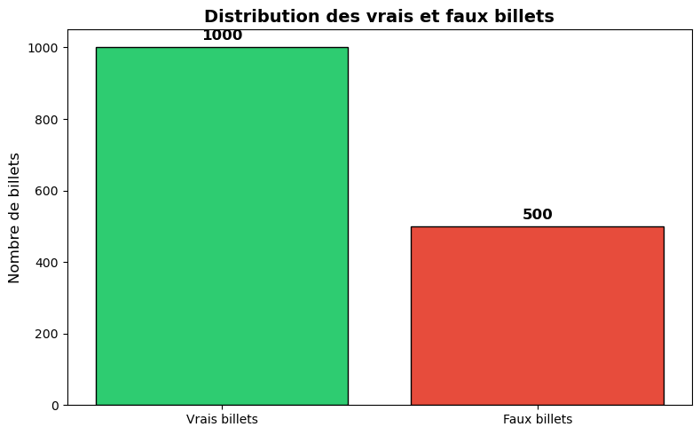

```python
# Distribution de la variable cible
print("DISTRIBUTION DE LA VARIABLE CIBLE (is_genuine)")
print("="*60)
distribution = df['is_genuine'].value_counts()
print(distribution)
print(f"\nProportion : {distribution[True]/len(df)*100:.1f}% vrais billets, {distribution[False]/len(df)*100:.1f}% faux billets")

# Visualisation
fig, ax = plt.subplots(figsize=(8, 5))
colors = ['#2ecc71', '#e74c3c']
bars = ax.bar(['Vrais billets', 'Faux billets'], [distribution[True], distribution[False]], color=colors, edgecolor='black')
ax.set_ylabel('Nombre de billets', fontsize=12)
ax.set_title('Distribution des vrais et faux billets', fontsize=14, fontweight='bold')
for bar, val in zip(bars, [distribution[True], distribution[False]]):
    ax.text(bar.get_x() + bar.get_width()/2, bar.get_height() + 20, str(val), ha='center', fontsize=12, fontweight='bold')
plt.tight_layout()
plt.show()
```

## Analyse des valeurs manquantes

```python
mask_NaN = df.isnull().any(axis=1)
print(" Répartition des valeurs manquantes par type de billet :")
print(df[mask_NaN]['is_genuine'].value_counts())
print("\n→ Les valeurs manquantes concernent principalement les VRAIS billets (29 vrais vs 8 faux)")
```

```
 Répartition des valeurs manquantes par type de billet :
is_genuine
True     29
False     8
Name: count, dtype: int64

→ Les valeurs manquantes concernent principalement les VRAIS billets (29 vrais vs 8 faux)
```

## Imputation des valeurs manquantes par régression linéaire

La variable `margin_low` contient 37 valeurs manquantes. Nous allons les imputer en utilisant une **régression linéaire multiple** basée sur les autres variables.

```python
df_imputed = df.dropna()
df_imputed['is_genuine'] = df_imputed['is_genuine'].astype(int)
```

```python
X = df_imputed.drop(columns=['is_genuine','margin_low'])
X["intercept"] = 1
y = df_imputed['margin_low']
```

```python
df_imputed
```

|  | is_genuine | diagonal | height_left | height_right | margin_low | margin_up | length |
| --- | --- | --- | --- | --- | --- | --- | --- |
| 0 | 1 | 171.81 | 104.86 | 104.95 | 4.52 | 2.89 | 112.83 |
| 1 | 1 | 171.46 | 103.36 | 103.66 | 3.77 | 2.99 | 113.09 |
| 2 | 1 | 172.69 | 104.48 | 103.50 | 4.40 | 2.94 | 113.16 |
| 3 | 1 | 171.36 | 103.91 | 103.94 | 3.62 | 3.01 | 113.51 |
| 4 | 1 | 171.73 | 104.28 | 103.46 | 4.04 | 3.48 | 112.54 |
| ... | ... | ... | ... | ... | ... | ... | ... |
| 1495 | 0 | 171.75 | 104.38 | 104.17 | 4.42 | 3.09 | 111.28 |
| 1496 | 0 | 172.19 | 104.63 | 104.44 | 5.27 | 3.37 | 110.97 |
| 1497 | 0 | 171.80 | 104.01 | 104.12 | 5.51 | 3.36 | 111.95 |
| 1498 | 0 | 172.06 | 104.28 | 104.06 | 5.17 | 3.46 | 112.25 |
| 1499 | 0 | 171.47 | 104.15 | 103.82 | 4.63 | 3.37 | 112.07 |

1463 rows × 7 columns

```python
results=sm.OLS(y,X).fit()
results.summary()
```

OLS Regression Results

| Dep. Variable: | margin_low | R-squared: | 0.477 |
| --- | --- | --- | --- |
| Model: | OLS | Adj. R-squared: | 0.476 |
| Method: | Least Squares | F-statistic: | 266.1 |
| Date: | Sun, 08 Feb 2026 | Prob (F-statistic): | 2.60e-202 |
| Time: | 15:55:33 | Log-Likelihood: | -1001.3 |
| No. Observations: | 1463 | AIC: | 2015. |
| Df Residuals: | 1457 | BIC: | 2046. |
| Df Model: | 5 |  |  |
| Covariance Type: | nonrobust |  |  |

|  | coef | std err | t | P>\|t\| | [0.025 | 0.975] |
| --- | --- | --- | --- | --- | --- | --- |
| diagonal | -0.1111 | 0.041 | -2.680 | 0.007 | -0.192 | -0.030 |
| height_left | 0.1841 | 0.045 | 4.113 | 0.000 | 0.096 | 0.272 |
| height_right | 0.2571 | 0.043 | 5.978 | 0.000 | 0.173 | 0.342 |
| margin_up | 0.2562 | 0.064 | 3.980 | 0.000 | 0.130 | 0.382 |
| length | -0.4091 | 0.018 | -22.627 | 0.000 | -0.445 | -0.374 |
| intercept | 22.9948 | 9.656 | 2.382 | 0.017 | 4.055 | 41.935 |

| Omnibus: | 73.627 | Durbin-Watson: | 1.893 |
| --- | --- | --- | --- |
| Prob(Omnibus): | 0.000 | Jarque-Bera (JB): | 95.862 |
| Skew: | 0.482 | Prob(JB): | 1.53e-21 |
| Kurtosis: | 3.801 | Cond. No. | 1.94e+05 |

Notes:  
[1] Standard Errors assume that the covariance matrix of the errors is correctly specified.  
[2] The condition number is large, 1.94e+05. This might indicate that there are  
strong multicollinearity or other numerical problems.

```python
x_pred=df[df.margin_low.isna()].drop(columns=['is_genuine','margin_low'])
x_pred['intercept']=1
df.loc[df.margin_low.isna(),'margin_low']=results.get_prediction(x_pred).summary_frame(0.05).loc[:,'mean']
df.info()
```

```
<class 'pandas.core.frame.DataFrame'>
RangeIndex: 1500 entries, 0 to 1499
Data columns (total 7 columns):
 #   Column        Non-Null Count  Dtype
---  ------        --------------  -----
 0   is_genuine    1500 non-null   bool
 1   diagonal      1500 non-null   float64
 2   height_left   1500 non-null   float64
 3   height_right  1500 non-null   float64
 4   margin_low    1500 non-null   float64
 5   margin_up     1500 non-null   float64
 6   length        1500 non-null   float64
dtypes: bool(1), float64(6)
memory usage: 71.9 KB
```

## Analyse exploratoire des données (EDA)

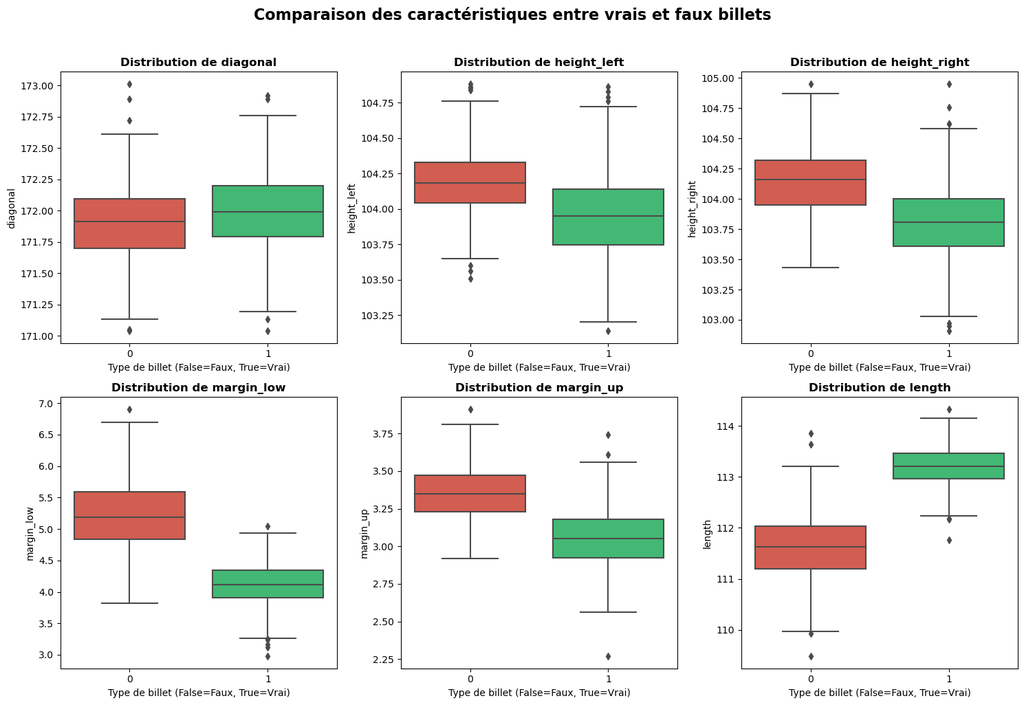

```python
# Distribution des variables par type de billet
features = ['diagonal', 'height_left', 'height_right', 'margin_low', 'margin_up', 'length']

fig, axes = plt.subplots(2, 3, figsize=(15, 10))
axes = axes.flatten()

for idx, feature in enumerate(features):
    ax = axes[idx]
    sns.boxplot(data=df_imputed, x='is_genuine', y=feature, ax=ax, palette=['#e74c3c', '#2ecc71'])
    ax.set_xlabel('Type de billet (False=Faux, True=Vrai)')
    ax.set_ylabel(feature)
    ax.set_title(f'Distribution de {feature}', fontweight='bold')

plt.suptitle('Comparaison des caractéristiques entre vrais et faux billets', fontsize=16, fontweight='bold', y=1.02)
plt.tight_layout()
plt.show()
```

### Observations clés :

- **`length`** : Les faux billets ont tendance à être plus courts que les vrais
- **`margin_low`** : Les faux billets ont des marges basses plus grandes
- **`margin_up`** : Les faux billets ont des marges hautes plus grandes

Ces variables semblent être les plus discriminantes pour distinguer les vrais des faux billets.

## Préparation des données

```python
# Séparation des features et de la cible
X = df.drop(columns=['is_genuine'])
y = df['is_genuine'].astype(int)  # Conversion en 0/1

print("Dimensions des données :")
print(f"   - Features (X) : {X.shape}")
print(f"   - Cible (y) : {y.shape}")
print(f"\n   Classes : 0 = Faux billet, 1 = Vrai billet")
```

```
Dimensions des données :
   - Features (X) : (1500, 6)
   - Cible (y) : (1500,)

   Classes : 0 = Faux billet, 1 = Vrai billet
```

```python
# Division en ensembles d'entraînement et de test
X_train, X_test, y_train, y_test = train_test_split(
    X, y,
    test_size=0.2,
    random_state=42,
    stratify=y  # Maintenir la proportion des classes
)

print("\n Division des données :")
print(f"   - Entraînement : {X_train.shape[0]} échantillons ({X_train.shape[0]/len(X)*100:.0f}%)")
print(f"   - Test : {X_test.shape[0]} échantillons ({X_test.shape[0]/len(X)*100:.0f}%)")
print(f"\n   Distribution dans l'ensemble de test :")
print(f"   - Vrais billets : {y_test.sum()} ({y_test.sum()/len(y_test)*100:.1f}%)")
print(f"   - Faux billets : {len(y_test) - y_test.sum()} ({(len(y_test) - y_test.sum())/len(y_test)*100:.1f}%)")
```

```
 Division des données :
   - Entraînement : 1200 échantillons (80%)
   - Test : 300 échantillons (20%)

   Distribution dans l'ensemble de test :
   - Vrais billets : 200 (66.7%)
   - Faux billets : 100 (33.3%)
```

```python
# Standardisation des données
scaler = StandardScaler()
X_train_scaled = scaler.fit_transform(X_train)
X_test_scaled = scaler.transform(X_test)


X_train_scaled = pd.DataFrame(X_train_scaled, columns=X_train.columns, index=X_train.index)
X_test_scaled = pd.DataFrame(X_test_scaled, columns=X_test.columns, index=X_test.index)

print("\n Standardisation effectuée (moyenne=0, écart-type=1)")
print("\nStatistiques après standardisation (ensemble d'entraînement) :")
print(X_train_scaled.describe().round(2).loc[['mean', 'std']])
```

```
 Standardisation effectuée (moyenne=0, écart-type=1)

Statistiques après standardisation (ensemble d'entraînement) :
      diagonal  height_left  height_right  margin_low  margin_up  length
mean       0.0         -0.0           0.0        -0.0        0.0    -0.0
std        1.0          1.0           1.0         1.0        1.0     1.0
```

## 7. Entraînement des modèles

Nous allons tester les 4 algorithmes recommandés :

1. **K-Means** (clustering - approche non supervisée)
2. **Régression Logistique** (classification)
3. **K-Nearest Neighbors (KNN)** (classification)
4. **Random Forest** (classification)

### K-Means (Clustering)

**Note importante** : K-Means est un algorithme de clustering non supervisé. Il ne connaît pas les vraies étiquettes. Nous l'utilisons ici pour voir s'il peut naturellement séparer les deux types de billets.

```python
# K-Means avec 2 clusters
kmeans = KMeans(n_clusters=2, random_state=42, n_init=10)
kmeans.fit(X_train_scaled)

# Prédictions
y_pred_kmeans_train = kmeans.predict(X_train_scaled)
y_pred_kmeans = kmeans.predict(X_test_scaled)

# K-Means peut inverser les labels (0 et 1), on vérifie et corrige si nécessaire
accuracy_direct = accuracy_score(y_test, y_pred_kmeans)
accuracy_flipped = accuracy_score(y_test, 1 - y_pred_kmeans)

if accuracy_flipped > accuracy_direct:
    y_pred_kmeans = 1 - y_pred_kmeans
    print(" Labels K-Means inversés pour correspondre aux vraies classes")

print("K-MEANS - Résultats")
print("="*60)
print(f"Accuracy K-Means : {accuracy_score(y_test, y_pred_kmeans)*100:.2f}%")
```

```
K-MEANS - Résultats
============================================================
Accuracy K-Means : 98.67%
```

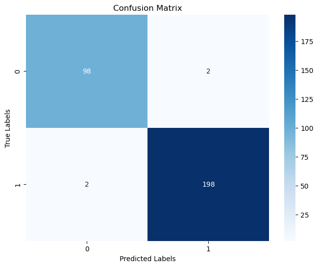

```python
confusion_matrix_kmeans = confusion_matrix(y_test, y_pred_kmeans)

plt.figure(figsize=(8, 6))
sns.heatmap(confusion_matrix_kmeans, annot=True, cmap="Blues", fmt="d")
plt.xlabel('Predicted Labels')
plt.ylabel('True Labels')
plt.title('Confusion Matrix')
plt.show()
```

### Régression Logistique

```python
# Régression Logistique avec sklearn (plus robuste que statsmodels pour la prédiction)
log_reg = LogisticRegression(random_state=42, max_iter=1000)
log_reg.fit(X_train_scaled, y_train)

# Prédictions
y_pred_logreg = log_reg.predict(X_test_scaled)
y_prob_logreg = log_reg.predict_proba(X_test_scaled)[:, 1]

print("RÉGRESSION LOGISTIQUE - Résultats")
print("="*60)
print(f"Accuracy : {accuracy_score(y_test, y_pred_logreg)*100:.2f}%")
```

```
RÉGRESSION LOGISTIQUE - Résultats
============================================================
Accuracy : 99.00%
```

[figure not shown]

```python
confusion_matrix_logreg = confusion_matrix(y_test,y_pred_logreg)
plt.figure(figsize=(8, 6))
sns.heatmap(confusion_matrix_kmeans, annot=True, cmap="Blues", fmt="d")
plt.xlabel('Predicted Labels')
plt.ylabel('True Labels')
plt.title('Confusion Matrix')
plt.show()
```

### K-Nearest Neighbors (KNN)

```python
# Recherche du meilleur k par validation croisée
k_range = range(1, 21)
cv_scores = []

for k in k_range:
    knn_temp = KNeighborsClassifier(n_neighbors=k)
    scores = cross_val_score(knn_temp, X_train_scaled, y_train, cv=5, scoring='accuracy')
    cv_scores.append(scores.mean())

# Meilleur k
best_k = k_range[np.argmax(cv_scores)]
print(f"KNN - Recherche du meilleur k")
print("="*60)
print(f"Meilleur k trouvé : {best_k} (accuracy CV = {max(cv_scores)*100:.2f}%)")
```

```
KNN - Recherche du meilleur k
============================================================
Meilleur k trouvé : 12 (accuracy CV = 99.25%)
```

```python
# Entraînement du KNN avec le meilleur k
knn = KNeighborsClassifier(n_neighbors=best_k)
knn.fit(X_train_scaled, y_train)

# Prédictions
y_pred_knn = knn.predict(X_test_scaled)
y_prob_knn = knn.predict_proba(X_test_scaled)[:, 1]

print(f" KNN (k={best_k}) - Modèle entraîné")
```

```
🟠 KNN (k=12) - Modèle entraîné
```

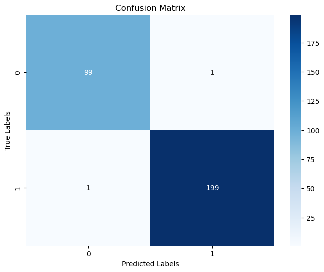

```python
confusion_matrix_knn = confusion_matrix(y_test,y_pred_knn)
plt.figure(figsize=(8, 6))
sns.heatmap(confusion_matrix_knn, annot=True, cmap="Blues", fmt="d")
plt.xlabel('Predicted Labels')
plt.ylabel('True Labels')
plt.title('Confusion Matrix')
plt.show()
```

```python
accuracy_knn = np.trace(confusion_matrix_knn) / np.sum(confusion_matrix_knn)
print("KNN - Résultats")
print("="*60)
print(f"The model accuracy is {accuracy_knn*100:.2f} %")
```

```
KNN - Résultats
============================================================
The model accuracy is 99.33 %
```

### Random Forest

```python
# Random Forest avec hyperparamètres optimisés
rf = RandomForestClassifier(
    n_estimators=100,
    max_depth=10,
    min_samples_split=5,
    min_samples_leaf=2,
    random_state=42,
    n_jobs=-1
)
rf.fit(X_train_scaled, y_train)

# Prédictions
y_pred_rf = rf.predict(X_test_scaled)
y_prob_rf = rf.predict_proba(X_test_scaled)[:, 1]

print("RANDOM FOREST - Résultats")
print("="*60)

# Importance des variables
importance_df = pd.DataFrame({
    'Variable': X_train.columns,
    'Importance': rf.feature_importances_
}).sort_values('Importance', ascending=False)

print("\nImportance des variables :")
print(importance_df.to_string(index=False))
```

```
RANDOM FOREST - Résultats
============================================================

Importance des variables :
    Variable  Importance
      length    0.496250
  margin_low    0.322136
   margin_up    0.096636
height_right    0.044648
 height_left    0.034278
    diagonal    0.006052
```

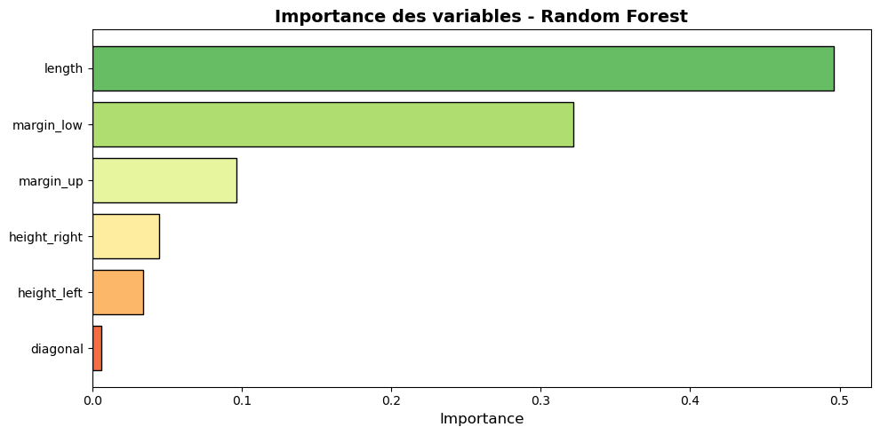

```python
plt.figure(figsize=(10, 5))
colors = plt.cm.RdYlGn(np.linspace(0.8, 0.2, len(importance_df)))
bars = plt.barh(importance_df['Variable'], importance_df['Importance'], color=colors, edgecolor='black')
plt.xlabel('Importance', fontsize=12)
plt.title('Importance des variables - Random Forest', fontsize=14, fontweight='bold')
plt.gca().invert_yaxis()
plt.tight_layout()
plt.show()
```

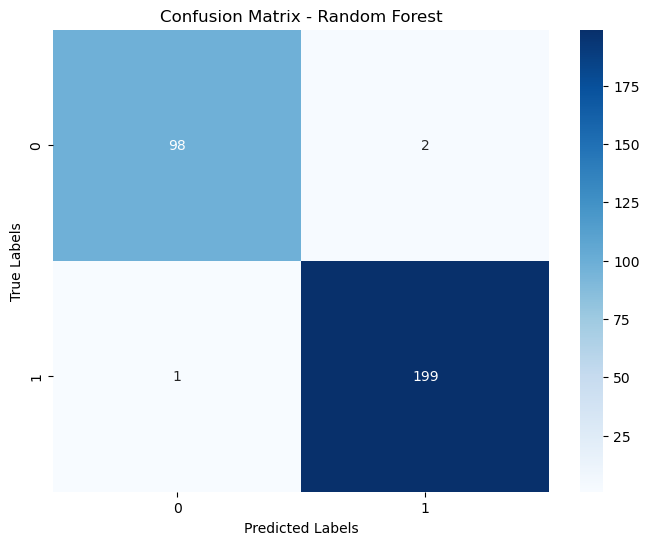

```python
confusion_matrix_rf = confusion_matrix(y_test, y_pred_rf)
plt.figure(figsize=(8, 6))
sns.heatmap(confusion_matrix_rf, annot=True, cmap="Blues", fmt="d")
plt.xlabel('Predicted Labels')
plt.ylabel('True Labels')
plt.title('Confusion Matrix - Random Forest')
plt.show()
```

```python
accuracy_rf = np.trace(confusion_matrix_rf) / np.sum(confusion_matrix_rf)
print("Random Forrest - Résultats")
print("="*60)
print(f"The model accuracy is {accuracy_rf*100:.2f} %")
```

```
Random Forrest - Résultats
============================================================
The model accuracy is 99.00 %
```

## Évaluation et comparaison des modèles

```python
# Fonction pour calculer toutes les métriques
def evaluate_model(y_true, y_pred, y_prob=None, model_name="Model"):
    metrics = {
        'Modèle': model_name,
        'Accuracy': accuracy_score(y_true, y_pred),
        'Precision': precision_score(y_true, y_pred),
        'Recall': recall_score(y_true, y_pred),
        'F1-Score': f1_score(y_true, y_pred),
    }
    if y_prob is not None:
        metrics['AUC-ROC'] = roc_auc_score(y_true, y_prob)
    else:
        metrics['AUC-ROC'] = None
    return metrics

# Évaluation de tous les modèles
results = []
results.append(evaluate_model(y_test, y_pred_kmeans, None, "K-Means"))
results.append(evaluate_model(y_test, y_pred_logreg, y_prob_logreg, "Régression Logistique"))
results.append(evaluate_model(y_test, y_pred_knn, y_prob_knn, f"KNN (k={best_k})"))
results.append(evaluate_model(y_test, y_pred_rf, y_prob_rf, "Random Forest"))

# Création du tableau comparatif
results_df = pd.DataFrame(results)
results_df = results_df.set_index('Modèle')

# Formatage en pourcentages
results_display = results_df.copy()
for col in results_display.columns:
    results_display[col] = results_display[col].apply(lambda x: f"{x*100:.2f}%" if x is not None else "N/A")

print("\n" + "="*80)
print(" TABLEAU COMPARATIF DES PERFORMANCES")
print("="*80)
print(results_display.to_string())
```

```
================================================================================
 TABLEAU COMPARATIF DES PERFORMANCES
================================================================================
                      Accuracy Precision  Recall F1-Score AUC-ROC
Modèle
K-Means                 98.67%    99.00%  99.00%   99.00%    nan%
Régression Logistique   99.00%    99.00%  99.50%   99.25%  99.95%
KNN (k=12)              99.33%    99.50%  99.50%   99.50%  99.94%
Random Forest           99.00%    99.00%  99.50%   99.25%  99.94%
```

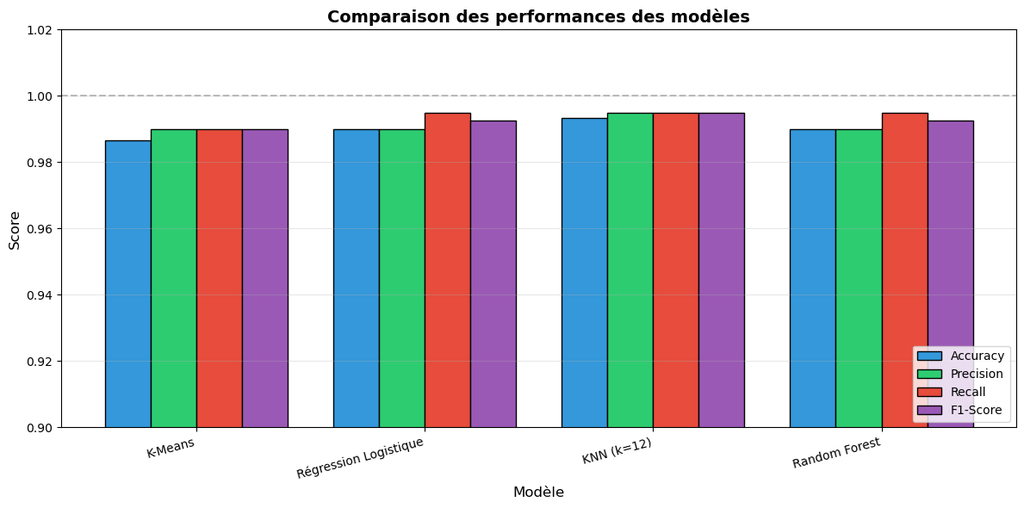

```python
# Visualisation comparative
fig, ax = plt.subplots(figsize=(12, 6))

metrics_to_plot = ['Accuracy', 'Precision', 'Recall', 'F1-Score']
x = np.arange(len(results_df.index))
width = 0.2

colors = ['#3498db', '#2ecc71', '#e74c3c', '#9b59b6']

for i, metric in enumerate(metrics_to_plot):
    values = results_df[metric].values
    ax.bar(x + i*width, values, width, label=metric, color=colors[i], edgecolor='black')

ax.set_xlabel('Modèle', fontsize=12)
ax.set_ylabel('Score', fontsize=12)
ax.set_title('Comparaison des performances des modèles', fontsize=14, fontweight='bold')
ax.set_xticks(x + width * 1.5)
ax.set_xticklabels(results_df.index, rotation=15, ha='right')
ax.legend(loc='lower right')
ax.set_ylim(0.9, 1.02)
ax.axhline(y=1.0, color='gray', linestyle='--', alpha=0.5)
ax.grid(axis='y', alpha=0.3)

plt.tight_layout()
plt.show()
```

## Sauvegarde du modèle final

```python
# Sauvegarde du modèle Random Forest et du scaler
joblib.dump(rf, 'modele_random_forest.pkl')
joblib.dump(scaler, 'scaler.pkl')

# Sauvegarde des colonnes pour la prédiction
joblib.dump(list(X_train.columns), 'features_columns.pkl')

print("\n✅ Modèles sauvegardés avec succès :")
print("   - modele_random_forest.pkl")
print("   - scaler.pkl")
print("   - features_columns.pkl")
```

```
✅ Modèles sauvegardés avec succès :
   - modele_random_forest.pkl
   - scaler.pkl
   - features_columns.pkl
```